# Fiber_Microbiome.Diet_Data

Jordan Mattke

7/29/2019

The first part of this data analysis provides analysis based ASA_24 data-RecallNo at 4 time points for KCAL, PROT, CARB, and TFAT

##ASA_24

```r
diet_data <-  read.delim("C:/Users/Jordan/Box/Diet Data/Final Study Dietary Data_ASA24/BFiber_2019-06-26_52817/BFiber_2019-06-26_52817_Totals_Mod.txt")
```

##Libraries

```r
#Libraries
library(tidyverse)
```

```r
library(ggplot2)
library(stats)
library(dplyr)
library(kableExtra)
```

##EasyVariables

```r
#Variables
KCAL <- diet_data$KCAL
PROT <- diet_data$PROT
CARB <- diet_data$CARB
TFAT <- diet_data$TFAT
Intervention <- diet_data$Intervention
Participant <- diet_data$UserName
Timepoint <- diet_data$RecallNo
KCAL.PROT<- diet_data$PROT*4
KCAL.CARB<- diet_data$CARB*4
KCAL.TFAT<- diet_data$TFAT*9
#The data table will now include the KCAL values for all nutrients
diet_data<- cbind(diet_data,KCAL.PROT,KCAL.CARB,KCAL.TFAT)
```

##ASA_24.GGPlots This section will focus on creating a visual representation of KCAL, PROT, CARB, and TFAT for each participant at each time point. NOTE: Most participants did not complete all 4 recalls.

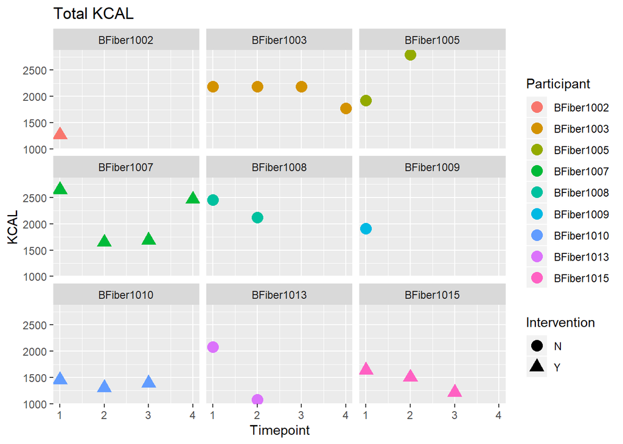

```r
#KCAL_GGPLOT
ggplot(data=diet_data, aes(x=Timepoint, y=KCAL, shape=Intervention, color=Participant))+
  geom_point(size=4)+
  labs(title="Total KCAL")+
  facet_wrap(vars(diet_data$UserName))
```

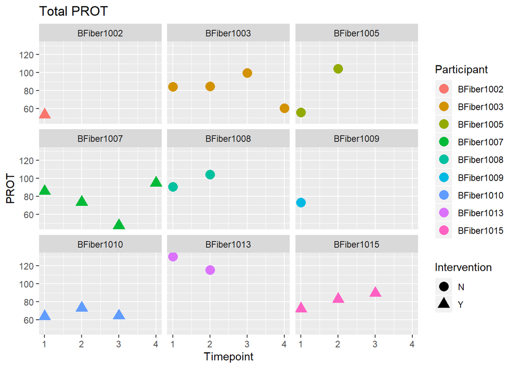

```r
#PROT_GGPLOT
ggplot(data = diet_data, aes(x=Timepoint, y=PROT, shape=Intervention, color=Participant))+
  geom_point(size=4)+
  labs(title="Total PROT")+
  facet_wrap(vars(diet_data$UserName))
```

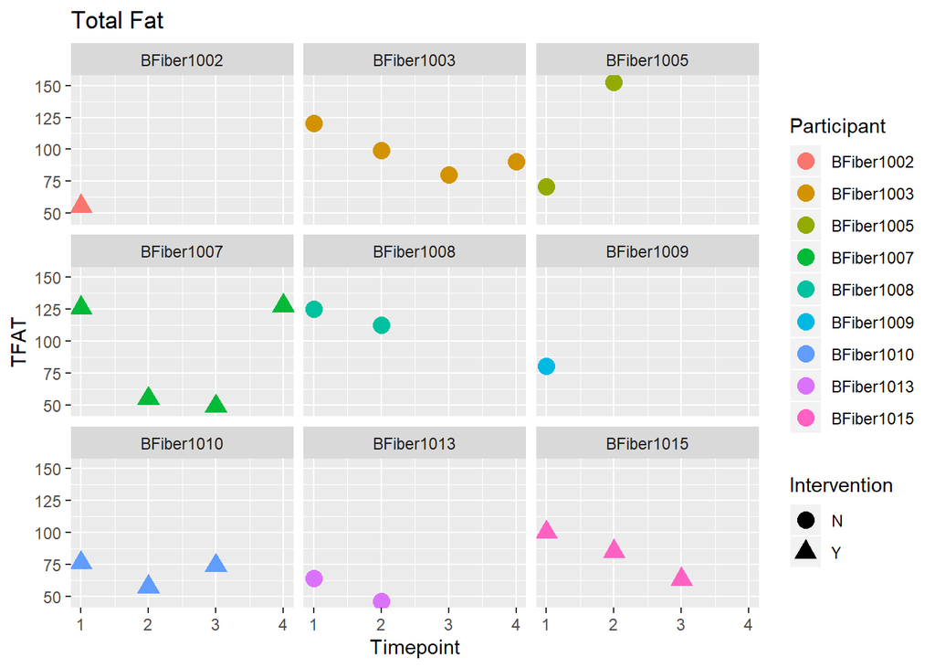

```r
#TFAT_GGPLOT
ggplot(data = diet_data, aes(x=Timepoint, y=TFAT, shape=Intervention, color=Participant))+
  geom_point(size=4)+
  labs(title="Total Fat")+
  facet_wrap(vars(diet_data$UserName))
```

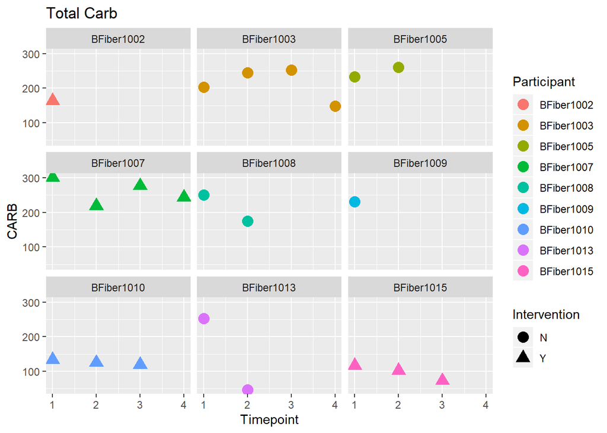

```r
#CARB_GGPLOT
ggplot(data = diet_data, aes(x=Timepoint, y=CARB, shape=Intervention, color=Participant))+
  geom_point(size=4)+
  facet_wrap(vars(diet_data$UserName))+
  labs(title="Total Carb")
```

##Shapiro.Wilks_Test

```r
#Shapiro-Wilks_Test_AllData
swKCAL <- shapiro.test(KCAL)
swPROT <- shapiro.test(PROT)
swCARB <- shapiro.test(CARB)
swTFAT <- shapiro.test(TFAT)
```

##Normalized Data Analysis The grams/1000 KCAL will be analyzed for outliers

```r
KCALNormalizer<- diet_data$KCAL/1000
diet_data$PROT.NORM<- diet_data$PROT/KCALNormalizer
diet_data$CARB.NORM<- diet_data$CARB/KCALNormalizer
diet_data$TFAT.NORM<- diet_data$TFAT/KCALNormalizer
```

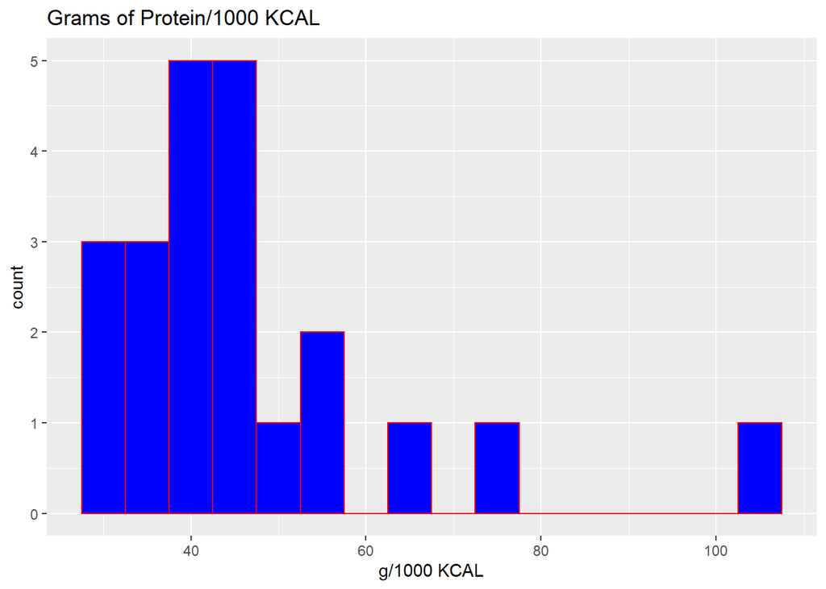

```r
#Protein
ggplot(data=diet_data, aes(x=diet_data$PROT.NORM))+
  geom_histogram(binwidth = 5, fill="blue", color="red")+
  labs(title="Grams of Protein/1000 KCAL", x= "g/1000 KCAL")+
  ggsave(filename="PROTOutliers.pdf")
```

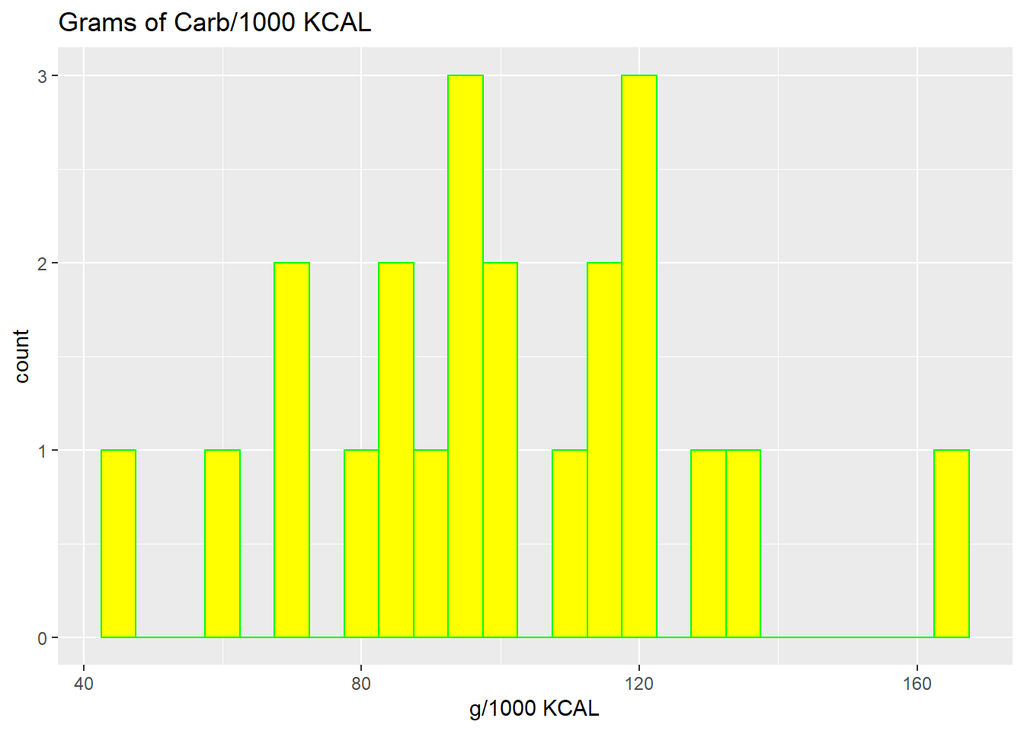

```r
#CARB
ggplot(data=diet_data, aes(x=diet_data$CARB.NORM))+
  geom_histogram(binwidth = 5, fill="yellow", color="green")+
  labs(title= "Grams of Carb/1000 KCAL", x="g/1000 KCAL")+
  ggsave(filename="CARBOutliers.pdf")
```

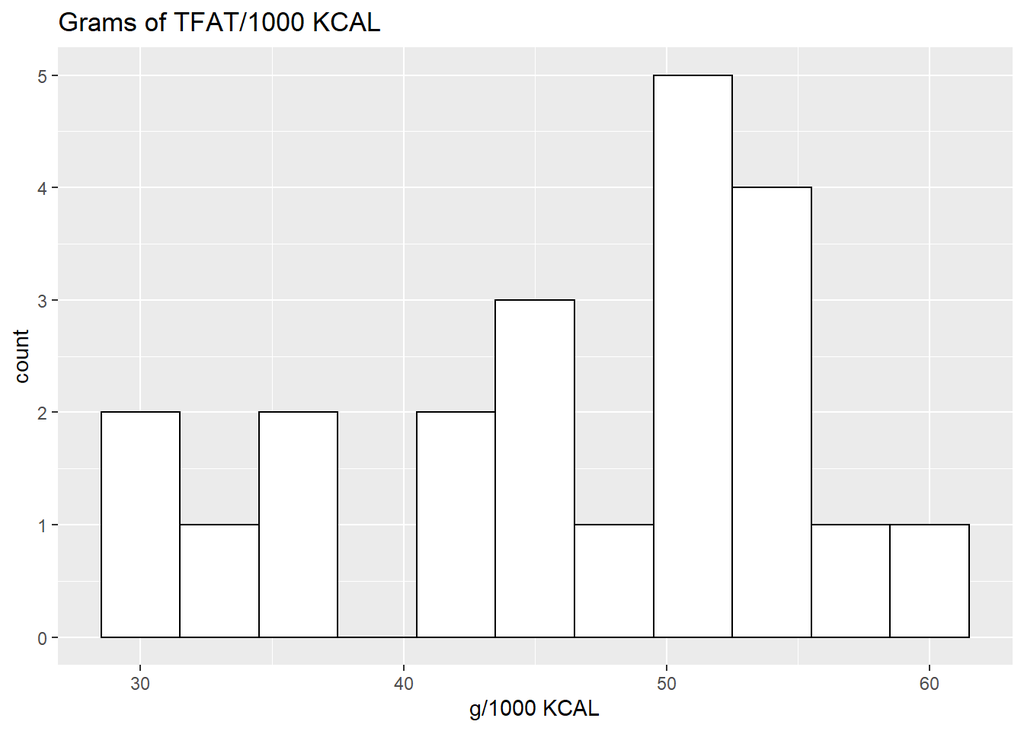

```r
#TFAT
ggplot(data=diet_data, aes(x=diet_data$TFAT.NORM))+
  geom_histogram(binwidth = 3, fill="white", color="black")+
  labs(title= "Grams of TFAT/1000 KCAL", x="g/1000 KCAL")+
  ggsave(filename="TFATOutliers.pdf")
```

##ASA_24.Timepoint_Summaries Each RecallNo will have all of the following calculations and tests performed for each time point: 1. Mean 2. Standard Deviation 3. Shapiro Wilks test for normality 5. Count for amount of data 6. Locate Outliers 7. Percentages of PROT, CARB, and TFAT in the diet at each RecallNo

```r
#Timepoint_1
t1data<- diet_data[Timepoint=="1", c("UserName", "KCAL", "PROT", "KCAL.PROT", "CARB", "KCAL.CARB", "TFAT", "KCAL.TFAT")] #Isolate only RecallNo==1
row.names(t1data)<-t1data$UserName
t1data<-t1data[,-1]#Remove duplicate UserNames
t1summary<-summary(t1data)
t1sd<- apply(t1data, 2, sd)#Standard Deviation of KCAL, PROT, CARB, and TFAT @T1
t1mean<- apply(t1data, 2, mean)#Mean of all T1 Columns
t1sw<- apply(t1data, 2, shapiro.test)#Shapiro Wilks Test for Each Column
t1outliers<- apply(t1data, 2, boxplot.stats) #Count/Outliers for T1
t1quantiles<- apply(t1data, 2, quantile)#quantiles
t1data<- rbind(t1data, t1mean, t1sd, t1outliers, t1quantiles)#Combine all data and analyses
t1data<- t1data[-c(12), ]
rownames(t1data)[10]<- "mean"
rownames(t1data)[11]<- "stdev"
rownames(t1data)[12]<- "count"
rownames(t1data)[13]<- "hinges"
rownames(t1data)[14]<- "outliers"
#Need to calculate the percentage of each nutrient based on the KCAL value of each nutrient
for (i in t1data){
  t1totalKCAL<- as.numeric(t1data[10,1])
  t1percentage<- t1mean/t1totalKCAL*100
}
t1data<-rbind(t1data,t1percentage)
row.names(t1data)[20]<- "percent"
t1data<- rbind(t1data, t1sw)
t1data<- t1data[-c(23:25),]
row.names(t1data)[22]<- 'p-value'
#Save Table
kable(t1data)%>%
  kable_styling(bootstrap_options = c("striped", "hover"))
```

|  | KCAL | PROT | KCAL.PROT | CARB | KCAL.CARB | TFAT | KCAL.TFAT |
| --- | --- | --- | --- | --- | --- | --- | --- |
| BFiber1002 | 1264.896304 | 53.11952491 | 212.47809964 | 163.8530305 | 655.412122 | 55.39913951 | 498.59225559 |
| BFiber1003 | 2185.530875 | 84.39575 | 337.583 | 202.4599025 | 809.83961 | 120.2021313 | 1081.8191817 |
| BFiber1005 | 1923.6407 | 55.906073 | 223.624292 | 233.1923915 | 932.769566 | 71.031522 | 639.283698 |
| BFiber1007 | 2646.0924 | 85.5155 | 342.062 | 301.047504 | 1204.190016 | 125.733358 | 1131.600222 |
| BFiber1008 | 2453.9135 | 90.70245 | 362.8098 | 251.15189 | 1004.60756 | 124.80808 | 1123.27272 |
| BFiber1009 | 1912.16575 | 73.2431575 | 292.97263 | 231.650865 | 926.60346 | 80.39665875 | 723.56992875 |
| BFiber1010 | 1456.1617 | 63.668114 | 254.672456 | 133.263275 | 533.0531 | 76.390964 | 687.518676 |
| BFiber1013 | 2081.823375 | 130.3475275 | 521.39011 | 252.0155525 | 1008.06221 | 64.13943125 | 577.25488125 |
| BFiber1015 | 1634.6735 | 72.31034 | 289.24136 | 116.34305 | 465.3722 | 100.32865 | 902.95785 |
| mean | 1950.98867822222 | 78.8009374344444 | 315.203749737778 | 209.441940111111 | 837.767760444444 | 90.9366594233333 | 818.42993481 |
| stdev | 450.848814505009 | 23.3474118252459 | 93.3896473009835 | 60.8264148002691 | 243.305659201076 | 27.392176847645 | 246.529591628805 |
| count | 9 | 9 | 9 | 9 | 9 | 9 | 9 |
| hinges | c(1633.5224825, 2213.7589175) | c(61.73686754, 84.74944746) | c(246.94747016, 338.99778984) | c(185.673465663333, 277.628264336667) | c(742.693862653333, 1110.51305734667) | c(54.500137852, 106.293179648) | c(490.501240668, 956.638616832) |
| outliers | numeric(0) | c(BFiber1013 = 130.3475275) | c(BFiber1013 = 521.39011) | numeric(0) | numeric(0) | numeric(0) | numeric(0) |
| 0% | 1264.896304 | 53.11952491 | 212.47809964 | 116.34305 | 465.3722 | 55.39913951 | 498.59225559 |
| 25% | 1634.6735 | 63.668114 | 254.672456 | 163.8530305 | 655.412122 | 71.031522 | 639.283698 |
| 50% | 1923.6407 | 73.2431575 | 292.97263 | 231.650865 | 926.60346 | 80.39665875 | 723.56992875 |
| 75% | 2185.530875 | 85.5155 | 342.062 | 251.15189 | 1004.60756 | 120.2021313 | 1081.8191817 |
| 100% | 2646.0924 | 130.3475275 | 521.39011 | 301.047504 | 1204.190016 | 125.733358 | 1131.600222 |
| percent | 100 | 4.03902587001424 | 16.156103480057 | 10.7351694271214 | 42.9406777084854 | 4.66105520951544 | 41.949496885639 |
| 21 | c(W = 0.97927710488961) | c(W = 0.88786946441757) | c(W = 0.88786946441757) | c(W = 0.947437456602682) | c(W = 0.947437456602682) | c(W = 0.890147894028309) | c(W = 0.890147894028309) |
| p-value | 0.960451630477929 | 0.189687830369484 | 0.189687830369484 | 0.661962080050722 | 0.661962080050722 | 0.200227285669175 | 0.200227285669175 |

```r
#Timepoint_2
t2data<- diet_data[Timepoint=="2", c("UserName", "KCAL", "PROT", "KCAL.PROT", "CARB", "KCAL.CARB", "TFAT", "KCAL.TFAT")] #Isolate only RecallNo==2
row.names(t2data)<-t2data$UserName
t2data<- t2data[,-1]#Remove duplicate UserNames
t2summary<-summary(t2data)
t2sd<- apply(t2data, 2, sd)#Standard Deviation of KCAL, PROT, CARB, and TFAT @T2
t2mean<- apply(t2data, 2, mean)#Mean of all T2 Columns
t2sw<- apply(t2data, 2, shapiro.test)#Shapiro Wilks Test for Each Column
t2outliers<- apply(t2data, 2, boxplot.stats)#Count/Outliers for T2
t2quantiles<- apply(t2data, 2, quantile)#quantiles
t2data<- rbind(t2data, t2mean, t2sd, t2outliers, t2quantiles)#Combine all data and analyses
t2data<- t2data[-10, ]#Getting rid of repeat data
rownames(t2data)[8]<- "mean"
rownames(t2data)[9]<- "stdev"
rownames(t2data)[10]<- "count"
rownames(t2data)[11]<- "hinges"
rownames(t2data)[12]<- "outliers"
#Need to calculate percentage of each nutrient based on KCAL value of each nutrient
for (i in t2data){
  t2totalKCAL<- as.numeric(t2data[8,1])
  t2percentage<- t2mean/t2totalKCAL*100
}
t2data<-rbind(t2data,t2percentage)
row.names(t2data)[18]<- "percent"
t2data<- rbind(t2data, t2sw)
t2data<- t2data[-c(21:22),]
row.names(t2data)[20]<- "p-value"
#Save Data
kable(t2data)%>%
  kable_styling(bootstrap_options = c("striped", "hover"))
```

|  | KCAL | PROT | KCAL.PROT | CARB | KCAL.CARB | TFAT | KCAL.TFAT |
| --- | --- | --- | --- | --- | --- | --- | --- |
| BFiber1003 | 2185.466247 | 84.586437 | 338.345748 | 244.2415266 | 976.9661064 | 99.04039684 | 891.36357156 |
| BFiber1005 | 2795.040975 | 104.2239795 | 416.895918 | 260.4243 | 1041.6972 | 152.5733008 | 1373.1597072 |
| BFiber1007 | 1648.0157 | 73.366942 | 293.467768 | 219.043936 | 876.175744 | 54.938042 | 494.442378 |
| BFiber1008 | 2120.90875 | 103.919245 | 415.67698 | 174.41741 | 697.66964 | 112.54303 | 1012.88727 |
| BFiber1010 | 1302.9715 | 73.19713 | 292.78852 | 124.98263 | 499.93052 | 57.78906 | 520.10154 |
| BFiber1013 | 1080.411674 | 115.1864333 | 460.7457332 | 46.85121833 | 187.40487332 | 46.4886 | 418.3974 |
| BFiber1015 | 1502.661394 | 83.02104036 | 332.08416144 | 102.5095372 | 410.0381488 | 85.40592884 | 768.65335956 |
| mean | 1805.06803428571 | 91.0716010228571 | 364.286404091429 | 167.495794018571 | 669.983176074286 | 86.9683369257143 | 782.715032331429 |
| stdev | 594.116650067332 | 16.6302570433956 | 66.5210281735825 | 79.3897881092264 | 317.559152436905 | 37.9082907750214 | 341.174616975193 |
| count | 7 | 7 | 7 | 7 | 7 | 7 | 7 |
| hinges | c(1199.90621351431, 2096.12518648569) | c(69.1327391714811, 100.040134828519) | c(276.530956685924, 400.160539314076) | c(104.011433978374, 244.823386021626) | c(416.045735913495, 979.293544086505) | c(55.8882276497941, 114.923630030206) | c(502.994048848147, 1034.31267027185) |
| outliers | numeric(0) | numeric(0) | numeric(0) | numeric(0) | numeric(0) | numeric(0) | numeric(0) |
| 0% | 1080.411674 | 73.19713 | 292.78852 | 46.85121833 | 187.40487332 | 46.4886 | 418.3974 |
| 25% | 1402.816447 | 78.19399118 | 312.77596472 | 113.7460836 | 454.9843344 | 56.363551 | 507.271959 |
| 50% | 1648.0157 | 84.586437 | 338.345748 | 174.41741 | 697.66964 | 85.40592884 | 768.65335956 |
| 75% | 2153.1874985 | 104.07161225 | 416.286449 | 231.6427313 | 926.5709252 | 105.79171342 | 952.12542078 |
| 100% | 2795.040975 | 115.1864333 | 460.7457332 | 260.4243 | 1041.6972 | 152.5733008 | 1373.1597072 |
| percent | 100 | 5.04532789307829 | 20.1813115723132 | 9.27919562238835 | 37.1167824895534 | 4.81800881040634 | 43.3620792936571 |
| 19 | c(W = 0.956209432980517) | c(W = 0.891552750026615) | c(W = 0.891552750026615) | c(W = 0.947601690195491) | c(W = 0.947601690195491) | c(W = 0.926517665158072) | c(W = 0.926517665158072) |
| p-value | 0.785632057205808 | 0.282861480134393 | 0.282861480134393 | 0.707828297823061 | 0.707828297823061 | 0.521687607733871 | 0.521687607733871 |

```r
#Timepoint_3
t3data<- diet_data[Timepoint=="3", c("UserName", "KCAL", "PROT", "KCAL.PROT", "CARB", "KCAL.CARB","TFAT","KCAL.TFAT")] #Isolate only RecallNo==3
row.names(t3data)<-t3data$UserName
t3data<-t3data[,-1]#Remove duplicate UserName
t3summary<-summary(t3data)
t3sd<- apply(t3data, 2, sd)#Standard Deviation of KCAL, PROT, CARB, and TFAT @ Recall 3
t3mean<- apply(t3data, 2, mean)#Mean of all macronutrients @ Recall 3
t3sw<- apply(t3data, 2, shapiro.test)#Shapiro Wilks Test for Each Column
t3outliers<- apply(t3data, 2, boxplot.stats)#Count and Outliers for Recall 3
t3quantiles<- apply(t3data, 2, quantile)#quantiles
t3data<- rbind(t3data, t3mean, t3sd, t3outliers, t3quantiles)#Combine all data and analyses
t3data<- t3data[-7, ]
row.names(t3data)[5]<- "mean"
row.names(t3data)[6]<- "stdev"
row.names(t3data)[7]<- "count"
row.names(t3data)[8]<- "hinges"
row.names(t3data)[9]<- "outliers"
#Need to calculate the percentage of each nutrient based on the KCAL value of each nutrient
for (i in t3data){
  t3totalKCAL<- as.numeric(t3data[5,1])
  t3percentage<- t3mean/t3totalKCAL*100
}
t3data<-rbind(t3data,t3percentage)
row.names(t3data)[15]<- "percent"
t3data<-rbind(t3data, t3sw)
t3data<- t3data[-c(18:19),]
row.names(t3data)[17]<- "p-value"
#Save Data
kable(t3data)%>%
  kable_styling(bootstrap_options = c("striped", "hover"))
```

|  | KCAL | PROT | KCAL.PROT | CARB | KCAL.CARB | TFAT | KCAL.TFAT |
| --- | --- | --- | --- | --- | --- | --- | --- |
| BFiber1003 | 2186.0124 | 99.531091 | 398.124364 | 253.032078 | 1012.128312 | 80.289685 | 722.607165 |
| BFiber1007 | 1689.4816 | 47.459824 | 189.839296 | 276.931664 | 1107.726656 | 48.914408 | 440.229672 |
| BFiber1010 | 1390.92947 | 64.3718142 | 257.4872568 | 119.4748692 | 477.8994768 | 74.1201753 | 667.0815777 |
| BFiber1015 | 1217.84825 | 89.479315 | 357.91726 | 72.9301775 | 291.72071 | 63.7631575 | 573.8684175 |
| mean | 1621.06793 | 75.21051105 | 300.8420442 | 180.592197175 | 722.3687887 | 66.77185645 | 600.94670805 |
| stdev | 424.025355191929 | 23.683097745165 | 94.7323909806599 | 99.7584874607491 | 399.033949842996 | 13.7194535015624 | 123.475081514062 |
| count | 4 | 4 | 4 | 4 | 4 | 4 | 4 |
| hinges | c(1039.8526044, 2040.5584656) | c(46.439951319, 107.411177881) | c(185.759805276, 429.644711524) | c(52.9177889565, 319.5891582435) | c(211.671155826, 1278.356632974) | c(52.457409954, 85.425922846) | c(472.116689586, 768.833305614) |
| outliers | numeric(0) | numeric(0) | numeric(0) | numeric(0) | numeric(0) | numeric(0) | numeric(0) |
| 0% | 1217.84825 | 47.459824 | 189.839296 | 72.9301775 | 291.72071 | 48.914408 | 440.229672 |
| 25% | 1347.659165 | 60.14381665 | 240.5752666 | 107.838696275 | 431.3547851 | 60.050970125 | 540.458731125 |
| 50% | 1540.205535 | 76.9255646 | 307.7022584 | 186.2534736 | 745.0138944 | 68.9416664 | 620.4749976 |
| 75% | 1813.6143 | 91.992259 | 367.969036 | 259.0069745 | 1036.027898 | 75.662552725 | 680.962974525 |
| 100% | 2186.0124 | 99.531091 | 398.124364 | 276.931664 | 1107.726656 | 80.289685 | 722.607165 |
| percent | 100 | 4.63956566274184 | 18.5582626509674 | 11.1403226128223 | 44.5612904512891 | 4.11900422026115 | 37.0710379823503 |
| 16 | c(W = 0.947897800830626) | c(W = 0.949113594135189) | c(W = 0.949113594135189) | c(W = 0.883586942972882) | c(W = 0.883586942972882) | c(W = 0.960261583541921) | c(W = 0.960261583541921) |
| p-value | 0.703010367887592 | 0.710583998460152 | 0.710583998460152 | 0.354182210832048 | 0.354182210832048 | 0.780555076453442 | 0.780555076453442 |

```r
#Timepoint_4
t4data<- diet_data[Timepoint=="4", c("UserName","KCAL", "PROT","KCAL.PROT","CARB","KCAL.CARB","TFAT","KCAL.TFAT")] #Isolate only RecallNo==4
row.names(t4data)<-t4data$UserName
t4data<-t4data[,-1]#Remove duplicate UserName column
t4summary<-summary(t4data)
t4sd<- apply(t4data, 2, sd)#Standard Deviation of KCAL, PROT, CARB, and TFAT @ REcall 4
t4mean<- apply(t4data, 2, mean)#Mean of all Recall 4 Columns
t4outliers<- apply(t4data, 2, boxplot.stats)#Count and Outliers for Recall 4
t4quantiles<- apply(t4data, 2, quantile)#quantiles
t4data<- rbind(t4data, t4mean, t4sd, t4outliers, t4quantiles)#Combine all data and analyses
t4data<- t4data[-5, ]
rownames(t4data)[3]<- "mean"
rownames(t4data)[4]<- "stdev"
rownames(t4data)[5]<- "count"
rownames(t4data)[6]<- "hinges"
rownames(t4data)[7]<- "outliers"
#Need to calculate the percentage of each nutrient based on the KCAL value of each nutrient
for (i in t4data){
  t4totalKCAL<- as.numeric(t4data[3,1])
  t4percentage<- t4mean/t4totalKCAL*100
}
t4data<-rbind(t4data,t4percentage)
row.names(t4data)[13]<- "percent"
#Save Data
kable(t4data)%>%
  kable_styling(bootstrap_options = c("striped", "hover"))
```

|  | KCAL | PROT | KCAL.PROT | CARB | KCAL.CARB | TFAT | KCAL.TFAT |
| --- | --- | --- | --- | --- | --- | --- | --- |
| BFiber1003 | 1772.2222 | 60.647205 | 242.58882 | 148.4528326 | 593.8113304 | 90.313288 | 812.819592 |
| BFiber1007 | 2465.278838 | 94.49733366 | 377.98933464 | 243.6224143 | 974.4896572 | 127.6491596 | 1148.8424364 |
| mean | 2118.750519 | 77.57226933 | 310.28907732 | 196.03762345 | 784.1504938 | 108.9812238 | 980.8310142 |
| stdev | 490.06504847615 | 23.9356555195231 | 95.7426220780924 | 67.2950565827572 | 269.180226331029 | 26.4004479898702 | 237.604031908832 |
| count | 2 | 2 | 2 | 2 | 2 | 2 | 2 |
| hinges | c(1344.44774240768, 2893.05329559232) | c(39.7539336091535, 115.390605050846) | c(159.015734436614, 461.562420203386) | c(89.7114340492437, 302.363812850756) | c(358.845736196975, 1209.45525140303) | c(67.268515976005, 150.693931623995) | c(605.416643784045, 1356.24538461595) |
| outliers | numeric(0) | numeric(0) | numeric(0) | numeric(0) | numeric(0) | numeric(0) | numeric(0) |
| 0% | 1772.2222 | 60.647205 | 242.58882 | 148.4528326 | 593.8113304 | 90.313288 | 812.819592 |
| 25% | 1945.4863595 | 69.109737165 | 276.43894866 | 172.245228025 | 688.9809121 | 99.6472559 | 896.8253031 |
| 50% | 2118.750519 | 77.57226933 | 310.28907732 | 196.03762345 | 784.1504938 | 108.9812238 | 980.8310142 |
| 75% | 2292.0146785 | 86.034801495 | 344.13920598 | 219.830018875 | 879.3200755 | 118.3151917 | 1064.8367253 |
| 100% | 2465.278838 | 94.49733366 | 377.98933464 | 243.6224143 | 974.4896572 | 127.6491596 | 1148.8424364 |
| percent | 100 | 3.6612271541348 | 14.6449086165392 | 9.25251093472416 | 37.0100437388967 | 5.14365532056302 | 46.2928978850671 |

##ASA_24.KCALProportions.geom_col Create a geom_col chart representing the proportions of PROT, CARB, and FAT Calorie proportions at each RecallNo. *Note: each bar represents proportions of a different sample size as sample size decreased at later RecallNo. The RecallNo==1 bar represents a sample size of 9 while the RecallNo==4 bar represents only a sample size of 2.

```r
#Each type of nutrient must have its own table before being merged to form one large data table for the geom_col chart
diet_data$CAL<- KCAL.PROT
diet_data$type<- "PROTEIN"
prot<- diet_data[,c("UserName","type", "RecallNo", "CAL")]

diet_data$CAL<- KCAL.CARB
diet_data$type<- "CARBOHYDRATE"
carb<- diet_data[,c("UserName", "type", "RecallNo", "CAL")]

diet_data$CAL<- KCAL.TFAT
diet_data$type<- "FAT"
tfat<- diet_data[,c("UserName", "type", "RecallNo", "CAL")]

#Combine the 3 nutrient KCAL tables from above
KCAL.Summary<- rbind(prot,carb,tfat)
```

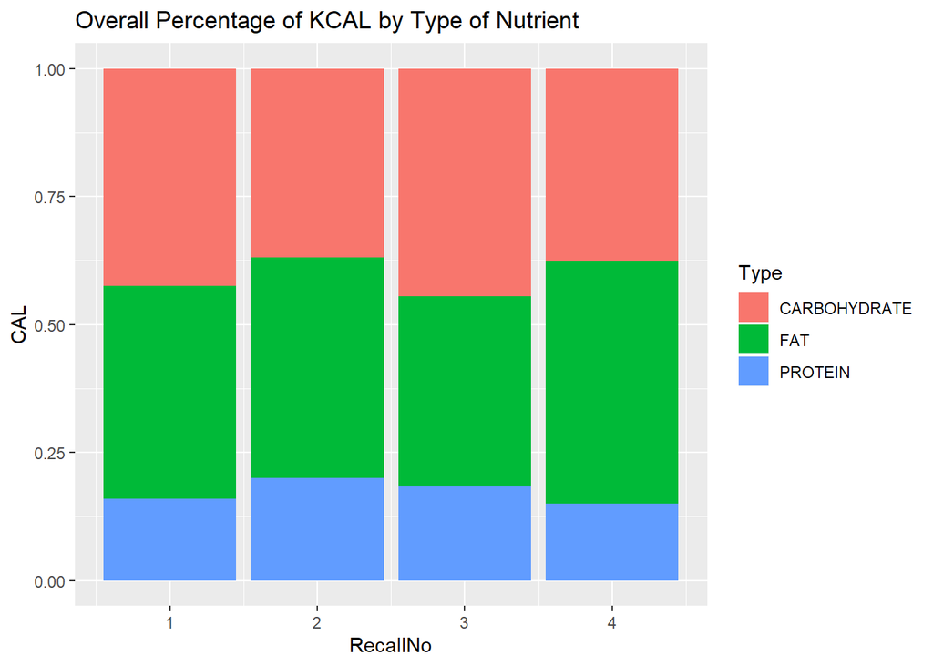

```r
CAL<-KCAL.Summary$CAL
RecallNo<- KCAL.Summary$RecallNo
Type<- KCAL.Summary$type

ggplot(data=KCAL.Summary, aes(x= RecallNo, y= CAL))+
  geom_col(aes(fill= Type), position="fill")+
  labs(title= "Overall Percentage of KCAL by Type of Nutrient")+
  ggsave(filename="OverallNutrientPerc.pdf")
```

##Individual_Timepoint_Breakdown The previous section gave an overall summary of all participants of KCAL intake by macronutrient. This section will create a facet wrap of geom_col charts showing amounts of each type of macronutrient for each individual participant at each time point.

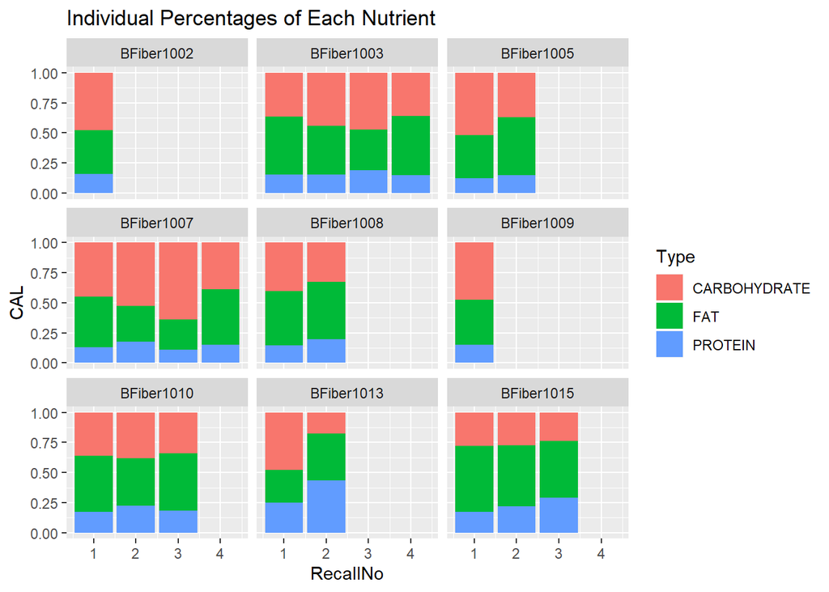

```r
#Use dataframe from previous section in order to create an individual breakdown by UserName
ggplot(data = KCAL.Summary, aes(x=RecallNo, y=CAL, fill= Type))+
  geom_col(position="fill")+
  facet_wrap(vars(KCAL.Summary$UserName))+
  labs(title="Individual Percentages of Each Nutrient")+
  ggsave(filename="IndividualNutrientPerc.pdf")
```

##ASA24.Fiber_Intake

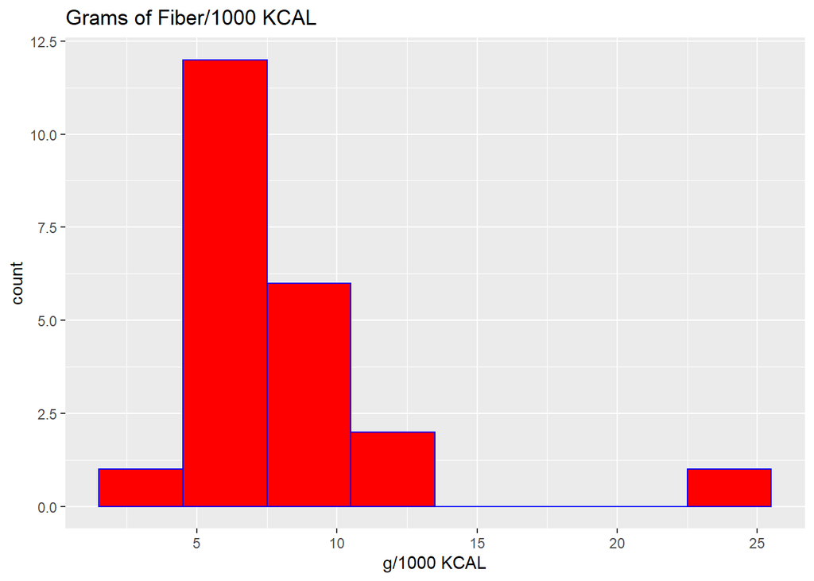

```r
#Isolate only Participants, KCAL, and FIBE for analysis
fiber_data<- diet_data[,c("UserName","RecallNo","KCAL","FIBE")]
KCALNormalizer<- (fiber_data$KCAL/1000)
g_per_1000KCAL<- fiber_data$FIBE/KCALNormalizer
fiber_data<- cbind(fiber_data, g_per_1000KCAL)
ggplot(data=fiber_data, aes(x=fiber_data$g_per_1000KCAL))+
  geom_histogram(binwidth = 3, fill="red", color="blue")+
  labs(title= "Grams of Fiber/1000 KCAL", x="g/1000 KCAL")+
  ggsave(filename="FiberOutliers.pdf")
```

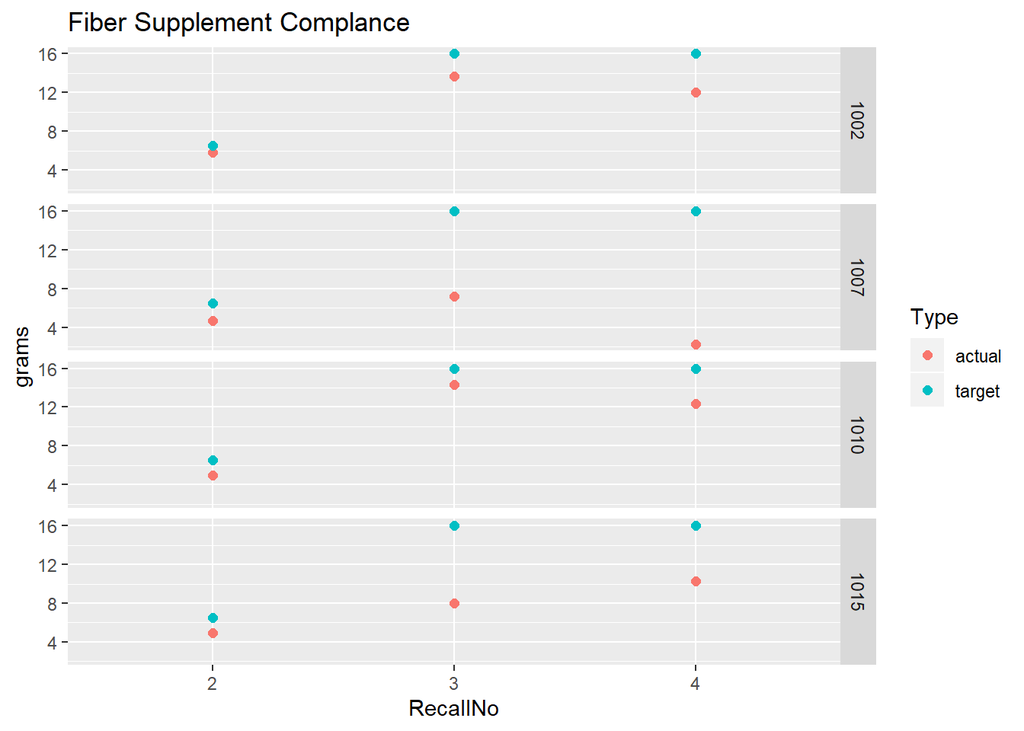

```r
compliance_data<- read.delim("C:/Users/Jordan/Box/Diet Data/Data_Fiber_Jul25_2019_MattkeMod.txt")
compliance<- compliance_data[compliance_data$intervention=="Y",]

compliance1act<-compliance[,c("Code", "g_average_wk4")]
colnames(compliance1act)[2]<-"grams"
compliance1act$actual<-"actual"
compliance1target<-compliance[,c("Code", "target_wk4")]
colnames(compliance1target)[2]<-"grams"
compliance1target$actual<-"target"
compliance1<- rbind(compliance1act,compliance1target)
compliance1$RecallNo<-"2"

compliance2act<-compliance[,c("Code", "g_average_wk8")]
colnames(compliance2act)[2]<-"grams"
compliance2act$actual<-"actual"
compliance2target<-compliance[,c("Code", "target_wk8")]
colnames(compliance2target)[2]<-"grams"
compliance2target$actual<-"target"
compliance2<- rbind(compliance2act,compliance2target)
compliance2$RecallNo<-"3"

compliance3act<-compliance[,c("Code", "g_average_wk12")]
colnames(compliance3act)[2]<-"grams"
compliance3act$actual<-"actual"
compliance3target<-compliance[,c("Code", "target_wk12")]
colnames(compliance3target)[2]<-"grams"
compliance3target$actual<-"target"
compliance3<- rbind(compliance3act,compliance3target)
compliance3$RecallNo<-"4"

compliance_sum<-rbind(compliance1, compliance2, compliance3)
Type<-compliance_sum$actual

ggplot(data=compliance_sum, aes(x=compliance_sum$RecallNo, y=compliance_sum$grams))+
  geom_point(aes(color=Type), size=2)+
  facet_grid(vars(compliance_sum$Code))+
  labs(title="Fiber Supplement Complance", x="RecallNo", y="grams")+
  ggsave(filename="SupplementCompliance.pdf")
```

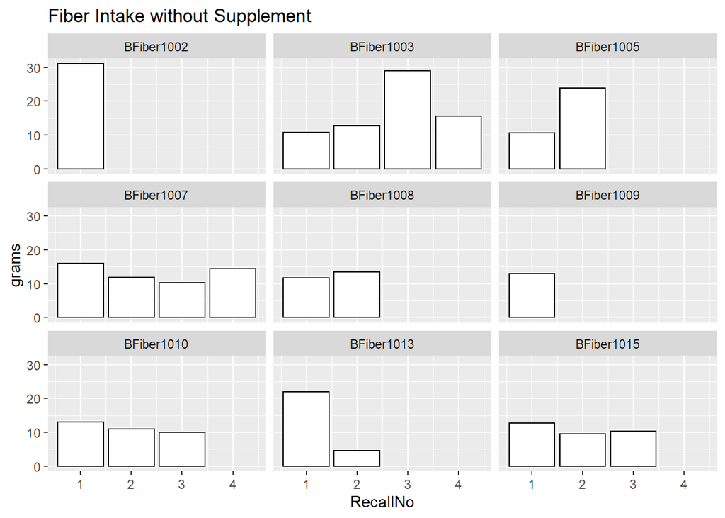

```r
#Total Fiber Intake
FibSupData1<- diet_data[,c("UserName","RecallNo","FIBE","KCAL")]
colnames(FibSupData1)[3]<-"grams"
FibSupData1$Source<-"Diet"

ggplot(data=FibSupData1, aes(x=FibSupData1$RecallNo, y=FibSupData1$grams))+
  geom_col(fill="white", color="black")+
  facet_wrap(vars(FibSupData1$UserName))+
  labs(title="Fiber Intake without Supplement", x="RecallNo", y="grams")+
  ggsave(filename="IndFiberNoSup.pdf")
```

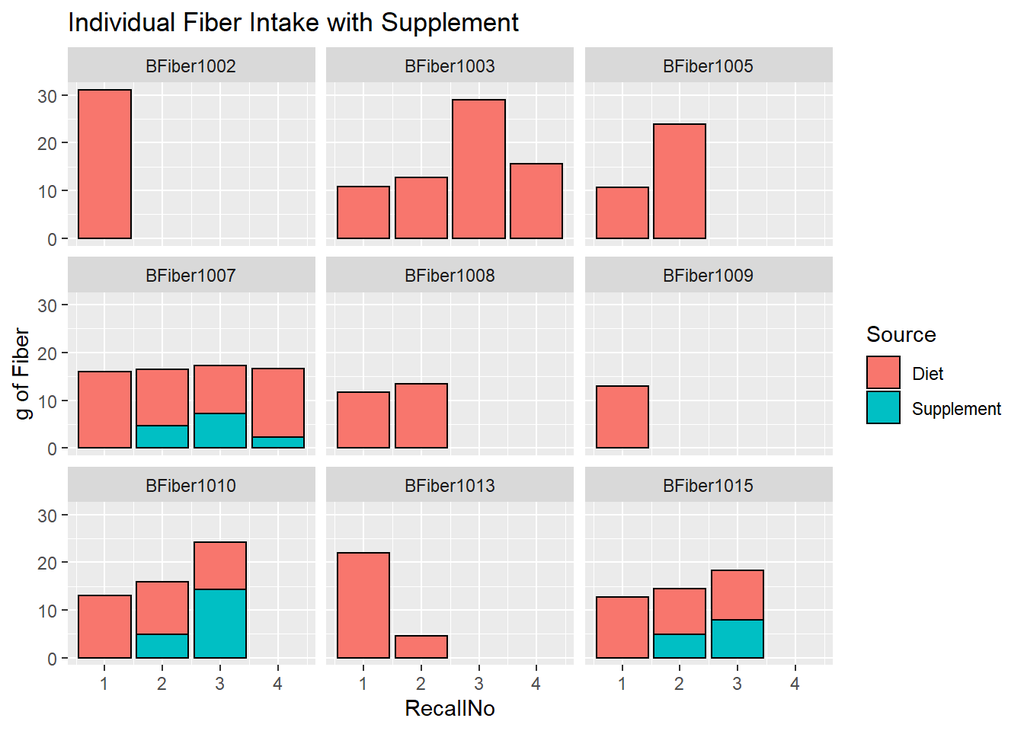

```r
FibSupData2<- diet_data[,c("UserName","RecallNo","FIBE_SUP","KCAL")]
colnames(FibSupData2)[3]<-"grams"
FibSupData2$Source<-"Supplement"

FibSupData<-rbind(FibSupData1,FibSupData2)
Source<-FibSupData$Source
#Plot of Supplement Fiber Data
ggplot(data=FibSupData, aes(x=FibSupData$RecallNo, y=FibSupData$grams, fill=Source))+
  geom_col(color="black")+
  facet_wrap(vars(fiber_data$UserName))+
  labs(title="Individual Fiber Intake with Supplement", x="RecallNo", y= "g of Fiber")+
  ggsave(filename="IndFiberSup.pdf")
```

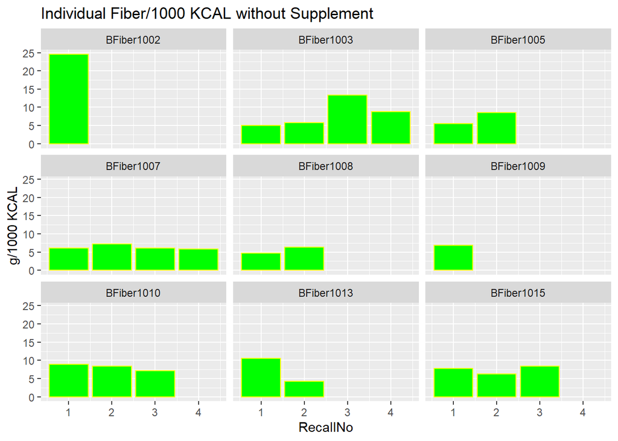

```r
#Fiber Intake in Proportion to KCAL
ggplot(data=fiber_data, aes(x=fiber_data$RecallNo, y=fiber_data$g_per_1000KCAL))+
  geom_col(fill="green", color="yellow")+
  facet_wrap(vars(fiber_data$UserName))+
  labs(title="Individual Fiber/1000 KCAL without Supplement", x="RecallNo", y= "g/1000 KCAL")+
  ggsave(filename="IndFiberNoSupNorm.pdf")
```

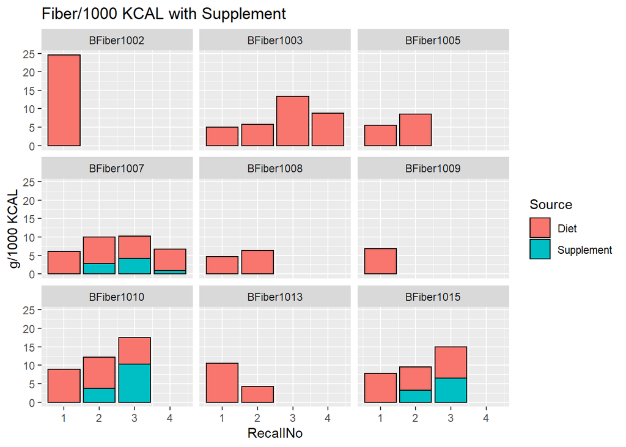

```r
#Fiber Intake in Proportion to KCAL with Supplement
KCALSupNormalizer<- FibSupData$KCAL/1000
FibSupData$g_per_1000KCAL<- FibSupData$grams/KCALSupNormalizer
ggplot(data=FibSupData, aes(x=FibSupData$RecallNo, y=FibSupData$g_per_1000KCAL, fill=Source))+
  geom_col(color="black")+
  facet_wrap(vars(FibSupData$UserName))+
  labs(title = "Fiber/1000 KCAL with Supplement", x="RecallNo", y="g/1000 KCAL")+
  ggsave(filename="IndFiberSupNorm.pdf")
```

##DHQIII_Results

```r
#DHQIII Import
diet_data2 <- read.delim("C:/Users/Jordan/Box/Diet Data/Final Study Dietary Data_DHQ/baylor_fiber_study.results.txt")
row.names(diet_data2)<-diet_data2$Respondent.ID
```

##DHQIII_Table The following table summarizes key data from DHQIII into “DHQIII.Summary” giving all of the following information about given data: 1. Mean 2. Standard Deviation 3. Quartiles 4. Count for amount of data 5. Outliers

```r
#All data of interest is located in columns 8:36
diet_data2mean<- apply(diet_data2[,8:36],2,mean)
diet_data2mean<- t(data.frame(diet_data2mean))#need to transcribe data for later dataframe
diet_data2sd<- apply(diet_data2[,8:36],2,sd)
diet_data2sd<- t(data.frame(diet_data2sd))#need to transcribe data for later dataframe
diet_data2quantiles<- apply(diet_data2[,8:36],2,quantile)#Quantiles
diet_data2outliers<- apply(diet_data2[,8:36],2, boxplot.stats)
#Merge Analysis into DHQIII dataframe
DHQIII.Summary<- rbind(diet_data2[,8:36],diet_data2mean, diet_data2sd, diet_data2quantiles, diet_data2outliers)
DHQIII.Summary<- DHQIII.Summary[-17, ]
row.names(DHQIII.Summary)[17]<- "count"
row.names(DHQIII.Summary)[18]<- "hinges"
row.names(DHQIII.Summary)[19]<- "outliers"
kable(DHQIII.Summary)%>%
  kable_styling(bootstrap_options = c("striped", "hover"))
```

|  | Energy..kcal. | X.Gluten..g. | Alcohol..g. | Protein..g. | X.Nitrogen..g. | X.Total.protein..g. | X.Animal.protein..g. | X.Vegetable.protein..g. | Total.fat..g. | X.Solid.fat..g. | Total.saturated.fatty.acids..g. | Total.monounsaturated.fatty.acids..g. | Total.polyunsaturated.fatty.acids..g. | X.Total.saturated.fatty.acids..g. | X.Total.monounsaturated.fatty.acids..g. | X.Total.polyunsaturated.fatty.acids..g. | X.Polyunsaturated.to.saturated.fatty.acid.ratio | Cholesterol..mg. | X.Cholesterol.to.saturated.fatty.acid.index | Carbohydrate..g. | Total.sugars..g. | X.Total.sugars..g. | X.Added.sugars..g. | X.Added.sugars.by.total.sugars..g. | X.Available.carbohydrate..g. | X.Glycemic.index.glucose.reference | X.Glycemic.index.bread.reference | X.Glycemic.load..glucose.reference. | X.Glycemic.load..bread.reference. |
| --- | --- | --- | --- | --- | --- | --- | --- | --- | --- | --- | --- | --- | --- | --- | --- | --- | --- | --- | --- | --- | --- | --- | --- | --- | --- | --- | --- | --- | --- |
| Fiber01 | 3545.22 | 9.57 | 11.31 | 206 | 33.96 | 211.1 | 166.52 | 44.58 | 138.17 | 57.72 | 39.47 | 52.83 | 30.75 | 42.56 | 53.65 | 29.54 | 45.79 | 662.26 | 76.39 | 357.87 | 134 | 139.81 | 89.53 | 78.96 | 321.46 | 1333.45 | 1906.43 | 191.61 | 273.95 |
| Fiber02 | 1058.7 | 3.11 | 1.73 | 34.66 | 5.79 | 35.58 | 18.05 | 17.52 | 36.76 | 12.77 | 9.35 | 16.25 | 8.19 | 9.14 | 13.75 | 7.86 | 17.04 | 308.16 | 24.39 | 148.75 | 75.1 | 76.49 | 68.06 | 60.88 | 134.96 | 681.37 | 973.69 | 81.56 | 116.55 |
| Fiber03 | 1749.97 | 2.87 | 4.94 | 44.98 | 7.4 | 45.8 | 29.89 | 15.91 | 47.72 | 25.16 | 17.13 | 17.17 | 9.01 | 17.55 | 17.66 | 8.64 | 15.41 | 104.42 | 22.93 | 281.43 | 204.3 | 205.15 | 195.98 | 174.65 | 275.64 | 1429.93 | 2043.19 | 176.63 | 252.4 |
| Fiber05 | 1445.29 | 8.62 | 5.31 | 66.45 | 10.62 | 66.04 | 47.43 | 18.61 | 64.85 | 38.56 | 19.68 | 25.18 | 14.87 | 19.83 | 25.79 | 12.33 | 13.9 | 501.69 | 44.84 | 140.22 | 36.22 | 39.19 | 32.54 | 30.82 | 127.56 | 393.24 | 562.07 | 81.71 | 116.8 |
| Fiber07 | 1538.58 | 5.56 | 0.01 | 51.68 | 8.06 | 49.49 | 33.98 | 15.51 | 56.68 | 31.48 | 19.72 | 19.14 | 12.54 | 20.51 | 21.93 | 11.44 | 9.01 | 185.51 | 29.88 | 209.79 | 135.92 | 136.2 | 131.36 | 117.9 | 205.49 | 992.24 | 1417.83 | 129.37 | 184.87 |
| Fiber09 | 1650.61 | 7.75 | 0.62 | 73.55 | 11.95 | 73.27 | 47.97 | 25.3 | 65.97 | 33.87 | 21.21 | 24.46 | 14.52 | 21.51 | 25.35 | 13.51 | 13.43 | 180.61 | 30.47 | 193.52 | 71.15 | 67.93 | 48.94 | 41.67 | 177.27 | 612.79 | 875.86 | 107.64 | 153.85 |
| Fiber10 | 1638.22 | 5.29 | 0 | 69.96 | 11.21 | 69.81 | 50.19 | 19.62 | 64.46 | 40.62 | 27.22 | 22.06 | 9.81 | 27.45 | 22.21 | 9 | 41.2 | 379.23 | 46.31 | 203.8 | 101.11 | 101.13 | 49.27 | 42.75 | 184.29 | 825.6 | 1180.32 | 106.67 | 152.49 |
| Fiber13 | 1708.71 | 6.61 | 0.53 | 75.85 | 11.99 | 74.02 | 48.64 | 25.38 | 68.03 | 29.06 | 18.45 | 28.01 | 15.48 | 19.47 | 29.04 | 13.53 | 26.67 | 212.85 | 30.21 | 204.42 | 80.05 | 79.03 | 58.55 | 55.58 | 184.52 | 858.57 | 1227.48 | 113.65 | 162.49 |
| Fiber15 | 1245.76 | 2.21 | 2.34 | 58.92 | 9.46 | 58.76 | 45.97 | 12.78 | 52.4 | 29.15 | 19.25 | 17.32 | 10.22 | 19.86 | 18.23 | 9.01 | 22.08 | 332.25 | 38.04 | 134.16 | 55.55 | 53.38 | 35.44 | 32.23 | 120.41 | 444 | 634.77 | 76.06 | 108.74 |
| diet_data2mean | 1731.22888888889 | 5.73222222222222 | 2.97666666666667 | 75.7833333333333 | 12.2711111111111 | 75.9855555555555 | 54.2933333333333 | 21.69 | 66.1155555555555 | 33.1544444444444 | 21.2755555555556 | 24.7133333333333 | 13.9322222222222 | 21.9866666666667 | 25.29 | 12.7622222222222 | 22.7255555555556 | 318.553333333333 | 38.1622222222222 | 208.217777777778 | 99.2666666666667 | 99.8122222222222 | 78.8522222222222 | 70.6044444444444 | 192.4 | 841.243333333333 | 1202.40444444444 | 118.322222222222 | 169.126666666667 |
| diet_data2sd | 717.06188108915 | 2.63650705374449 | 3.7064943005487 | 50.7293201708834 | 8.40989364445895 | 52.3768952189587 | 43.4766077908569 | 9.5704584529687 | 28.89022979794 | 12.2677097609039 | 8.2373783922907 | 11.3081298188516 | 6.8590374284184 | 9.05363324859142 | 11.622251287939 | 6.65052211818324 | 12.8817032172682 | 176.566474804817 | 16.5267017110022 | 72.1568797443767 | 51.496546486148 | 52.2553640255663 | 53.5232918405104 | 47.5932419338899 | 67.8229791442399 | 362.012426513235 | 517.358150126948 | 41.2956925047207 | 59.0268665524437 |
| 0% | 1058.7 | 2.21 | 0 | 34.66 | 5.79 | 35.58 | 18.05 | 12.78 | 36.76 | 12.77 | 9.35 | 16.25 | 8.19 | 9.14 | 13.75 | 7.86 | 9.01 | 104.42 | 22.93 | 134.16 | 36.22 | 39.19 | 32.54 | 30.82 | 120.41 | 393.24 | 562.07 | 76.06 | 108.74 |
| 25% | 1445.29 | 3.11 | 0.53 | 51.68 | 8.06 | 49.49 | 33.98 | 15.91 | 52.4 | 29.06 | 18.45 | 17.32 | 9.81 | 19.47 | 18.23 | 9 | 13.9 | 185.51 | 29.88 | 148.75 | 71.15 | 67.93 | 48.94 | 41.67 | 134.96 | 612.79 | 875.86 | 81.71 | 116.8 |
| 50% | 1638.22 | 5.56 | 1.73 | 66.45 | 10.62 | 66.04 | 47.43 | 18.61 | 64.46 | 31.48 | 19.68 | 22.06 | 12.54 | 19.86 | 22.21 | 11.44 | 17.04 | 308.16 | 30.47 | 203.8 | 80.05 | 79.03 | 58.55 | 55.58 | 184.29 | 825.6 | 1180.32 | 107.64 | 153.85 |
| 75% | 1708.71 | 7.75 | 4.94 | 73.55 | 11.95 | 73.27 | 48.64 | 25.3 | 65.97 | 38.56 | 21.21 | 25.18 | 14.87 | 21.51 | 25.79 | 13.51 | 26.67 | 379.23 | 44.84 | 209.79 | 134 | 136.2 | 89.53 | 78.96 | 205.49 | 992.24 | 1417.83 | 129.37 | 184.87 |
| 100% | 3545.22 | 9.57 | 11.31 | 206 | 33.96 | 211.1 | 166.52 | 44.58 | 138.17 | 57.72 | 39.47 | 52.83 | 30.75 | 42.56 | 53.65 | 29.54 | 45.79 | 662.26 | 76.39 | 357.87 | 204.3 | 205.15 | 195.98 | 174.65 | 321.46 | 1429.93 | 2043.19 | 191.61 | 273.95 |
| count | 9 | 9 | 9 | 9 | 9 | 9 | 9 | 9 | 9 | 9 | 9 | 9 | 9 | 9 | 9 | 9 | 9 | 9 | 9 | 9 | 9 | 9 | 9 | 9 | 9 | 9 | 9 | 9 | 9 |
| hinges | c(1499.48546666667, 1776.95453333333) | c(3.11626666666667, 8.00373333333333) | c(-0.5926, 4.0526) | c(54.9318, 77.9682) | c(8.57126666666667, 12.6687333333333) | c(53.5158666666667, 78.5641333333333) | c(39.7090666666667, 55.1509333333333) | c(13.6646, 23.5554) | c(57.3131333333333, 71.6068666666667) | c(26.4766666666667, 36.4833333333333) | c(18.2264, 21.1336) | c(17.9204, 26.1996) | c(9.87506666666667, 15.2049333333333) | c(18.7856, 20.9344) | c(18.2284, 26.1916) | c(9.06473333333333, 13.8152666666667) | c(10.3144666666667, 23.7655333333333) | c(206.134133333333, 410.185866666667) | c(22.5910666666667, 38.3489333333333) | c(171.652266666667, 235.947733333333) | c(46.949, 113.151) | c(43.0744666666667, 114.985533333333) | c(37.1726, 79.9274) | c(35.9406, 75.2194) | c(147.1442, 221.4358) | c(625.756333333333, 1025.44366666667) | c(894.882466666667, 1465.75753333333) | c(82.5390666666667, 132.740933333333) | c(117.9998, 189.7002) |
| outliers | c(Fiber01 = 3545.22) | numeric(0) | numeric(0) | c(Fiber01 = 206) | c(Fiber01 = 33.96) | c(Fiber01 = 211.1) | c(Fiber01 = 166.52) | c(Fiber01 = 44.58) | c(Fiber01 = 138.17) | c(Fiber01 = 57.72, Fiber02 = 12.77) | c(Fiber01 = 39.47, Fiber02 = 9.35, Fiber10 = 27.22) | c(Fiber01 = 52.83) | c(Fiber01 = 30.75) | c(Fiber01 = 42.56, Fiber02 = 9.14, Fiber10 = 27.45) | c(Fiber01 = 53.65) | c(Fiber01 = 29.54) | numeric(0) | numeric(0) | c(Fiber01 = 76.39) | c(Fiber01 = 357.87) | numeric(0) | numeric(0) | c(Fiber03 = 195.98) | c(Fiber03 = 174.65) | c(Fiber01 = 321.46) | numeric(0) | numeric(0) | numeric(0) | numeric(0) |

##DHQIII_Fiber_Analysis Soluble and insoluble fiber intake based on DHQIII

```r
Sol.Fiber<-diet_data2[,c("Respondent.ID","X.Soluble.dietary.fiber..g.")]
Sol.Fiber$Type<-"Soluble"
colnames(Sol.Fiber)[2]<-"grams"

Ins.Fiber<-diet_data2[,c("Respondent.ID","X.Insoluble.dietary.fiber..g.")]
Ins.Fiber$Type<-"Insoluble"
colnames(Ins.Fiber)[2]<-"grams"

CombinedFiber<-rbind(Sol.Fiber,Ins.Fiber)
```

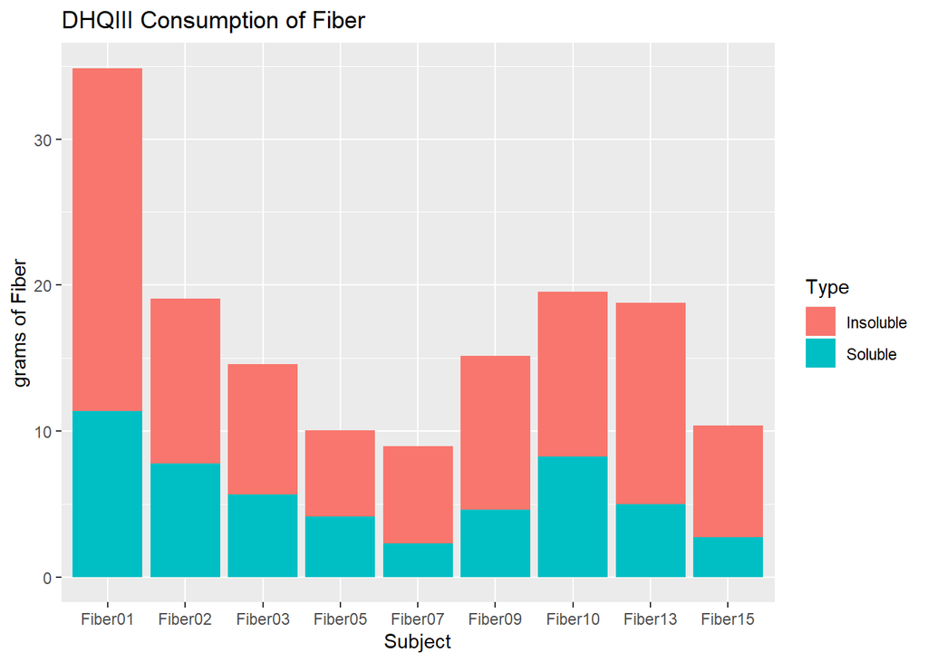

```r
Type<- CombinedFiber$Type
ggplot(data=CombinedFiber, aes(x=CombinedFiber$Respondent.ID, y=CombinedFiber$grams, fill=Type))+
  geom_col(position="stack")+
  labs(title= "DHQIII Consumption of Fiber", x= "Subject", y= "grams of Fiber")+
  ggsave(filename= "DHQIIIFiberConsumpiton.pdf")
```

```r
DHQIIIFiber<-diet_data2[, c("Respondent.ID", "X.Total.dietary.fiber..g.", "X.Soluble.dietary.fiber..g.", "X.Insoluble.dietary.fiber..g.")]
#Calculate percentage Soluble Fiber
TotalFiber<-diet_data2$X.Total.dietary.fiber..g.
Percent.Sol<- diet_data2$X.Soluble.dietary.fiber..g./TotalFiber*100 #Calculate percentage of Soluble Fiber
Percent.Insol<-DHQIIIFiber$X.Insoluble.dietary.fiber..g./TotalFiber*100 #Calculate percentage of Insoluble Fiber
DHQIIIFiber<- cbind(DHQIIIFiber, Percent.Sol, Percent.Insol)
DHQIIIFiber<-DHQIIIFiber[,-1]#Eliminating duplicate data
kable(DHQIIIFiber)%>%
  kable_styling(bootstrap_options = "striped", "hover")
```

|  | X.Total.dietary.fiber..g. | X.Soluble.dietary.fiber..g. | X.Insoluble.dietary.fiber..g. | Percent.Sol | Percent.Insol |
| --- | --- | --- | --- | --- | --- |
| Fiber01 | 34.91 | 11.38 | 23.49 | 32.59811 | 67.28731 |
| Fiber02 | 19.09 | 7.77 | 11.29 | 40.70194 | 59.14091 |
| Fiber03 | 14.55 | 5.67 | 8.93 | 38.96907 | 61.37457 |
| Fiber05 | 10.05 | 4.15 | 5.88 | 41.29353 | 58.50746 |
| Fiber07 | 8.97 | 2.29 | 6.66 | 25.52954 | 74.24749 |
| Fiber09 | 15.09 | 4.62 | 10.51 | 30.61630 | 69.64877 |
| Fiber10 | 19.51 | 8.23 | 11.32 | 42.18350 | 58.02153 |
| Fiber13 | 18.89 | 4.99 | 13.78 | 26.41609 | 72.94865 |
| Fiber15 | 10.34 | 2.72 | 7.64 | 26.30561 | 73.88781 |